# Bayesian statistics

## Note

- please install http://jasp-stats.org
- and Mplus if you like (on the stick)
- if you're a hacker, git clone the repo **dostodabsi/bayes_workshop**
- otherwise wait for the USB-stick; all materials are on there

## Statistics

## Statistics

[figure not shown]

- There is no *truth*
- No *correct way*
- Everyone does different things
- So what?

## Statistics

Silberzahn, R., et al. (2015). Crowdsourcing data analysis: Do soccer referees give more red cards to dark skin toned players? Center for Open Science, https://osf.io/j5v8f/

- 29 teams of statisticans around the world
- Same data set, same question

[figure not shown]

- What do they do?

## Statistics

- What would you do?

[figure not shown]

## Statistics

- What do they do?

[figure not shown]

## Statistics

- What do they find?

[figure not shown]

## Statistics

- So what?
- There is a **reproducibility crisis** in Psychology
  - **Partially due to statistics practices!**
- Statistics is a crucial part of our current approach to empirical science.
- Statistics **can** be useful.

## Bayesian Statistics

## Outline

- A few remarks on the "replication crisis" in psychology
- **Statistics: The Status Quo**
  - 1.1 An Example
  - 1.2 Notes on the history of statistics
- **Problems with current statistical practices**
  - 2.1 p-Value Hypothesis Testing
  - 2.2 Confidence intervals: A Solution?

## Outline

- **The principled Bayesian**
  - 3.1 Probability and Bayes' rule
  - 3.2 Binomial example (coin tosses – what else?)
  - 3.4 Model comparison using Bayes factor
- **The practical Bayesian**
  - 4.1 Creativity example
  - 4.2 Monte Carlo methods
  - 4.3 Markov chain Monte Carlo methods
  - 4.4 Model adequacy and posterior predictive checks

## Outline

- **Software for Bayesian data analysis**
  - 5.1 JASP: Examples
  - 5.2 JASP: Practice
  - 5.2 Demo: Bayesian SEM
- **Discussion**
  - Outlook
  - Questions

## Statistics: The Status Quo

## The Status Quo in Statistics

## A Bird's Eye View

| Classical Statistics | Bayesian Statistics |
| --- | --- |
| Ad-hoc | . |
| . | . |
| . | . |
| . | . |
| . | . |
| . | . |
| . | . |

borrowed from EJ Wagenmakers

## A Bird's Eye View

| Classical Statistics | Bayesian Statistics |
| --- | --- |
| Ad-hoc | Axiomatic |
| . | . |
| . | . |
| . | . |
| . | . |
| . | . |
| . | . |

borrowed from EJ Wagenmakers

## A Bird's Eye View

| Classical Statistics | Bayesian Statistics |
| --- | --- |
| Ad-hoc | Axiomatic |
| Incoherent | . |
| . | . |
| . | . |
| . | . |
| . | . |
| . | . |

borrowed from EJ Wagenmakers

## A Bird's Eye View

| Classical Statistics | Bayesian Statistics |
| --- | --- |
| Ad-hoc | Axiomatic |
| Incoherent | Coherent |
| . | . |
| . | . |
| . | . |
| . | . |
| . | . |

borrowed from EJ Wagenmakers

## A Bird's Eye View

| Classical Statistics | Bayesian Statistics |
| --- | --- |
| Ad-hoc | Axiomatic |
| Incoherent | Coherent |
| Paradoxical | . |
| . | . |
| . | . |
| . | . |
| . | . |

borrowed from EJ Wagenmakers

## A Bird's Eye View

| Classical Statistics | Bayesian Statistics |
| --- | --- |
| Ad-hoc | Axiomatic |
| Incoherent | Coherent |
| Paradoxical | Intuitive |
| . | . |
| . | . |
| . | . |
| . | . |

borrowed from EJ Wagenmakers

## A Bird's Eye View

| Classical Statistics | Bayesian Statistics |
| --- | --- |
| Ad-hoc | Axiomatic |
| Incoherent | Coherent |
| Paradoxical | Intuitive |
| Irrational | . |
| . | . |
| . | . |
| . | . |

borrowed from EJ Wagenmakers

## A Bird's Eye View

| Classical Statistics | Bayesian Statistics |
| --- | --- |
| Ad-hoc | Axiomatic |
| Incoherent | Coherent |
| Paradoxical | Intuitive |
| Irrational | Rational |
| . | . |
| . | . |
| . | . |

borrowed from EJ Wagenmakers

## A Bird's Eye View

| Classical Statistics | Bayesian Statistics |
| --- | --- |
| Ad-hoc | Axiomatic |
| Incoherent | Coherent |
| Paradoxical | Intuitive |
| Irrational | Rational |
| Ugly | . |
| . | . |
| . | . |

borrowed from EJ Wagenmakers

## A Bird's Eye View

| Classical Statistics | Bayesian Statistics |
| --- | --- |
| Ad-hoc | Axiomatic |
| Incoherent | Coherent |
| Paradoxical | Intuitive |
| Irrational | Rational |
| Ugly | Pretty |
| . | . |
| . | . |

borrowed from EJ Wagenmakers

## A Bird's Eye View

| Classical Statistics | Bayesian Statistics |
| --- | --- |
| Ad-hoc | Axiomatic |
| Incoherent | Coherent |
| Paradoxical | Intuitive |
| Irrational | Rational |
| Ugly | Pretty |
| Irrelevant | . |
| . | . |

borrowed from EJ Wagenmakers

## A Bird's Eye View

| Classical Statistics | Bayesian Statistics |
| --- | --- |
| Ad-hoc | Axiomatic |
| Incoherent | Coherent |
| Paradoxical | Intuitive |
| Irrational | Rational |
| Ugly | Pretty |
| Irrelevant | Relevant |
| . | . |

borrowed from EJ Wagenmakers

## A Bird's Eye View

| Classical Statistics | Bayesian Statistics |
| --- | --- |
| Ad-hoc | Axiomatic |
| Incoherent | Coherent |
| Paradoxical | Intuitive |
| Irrational | Rational |
| Ugly | Pretty |
| Irrelevant | Relevant |
| what's taught | . |

borrowed from EJ Wagenmakers

## A Bird's Eye View

| Classical Statistics | Bayesian Statistics |
| --- | --- |
| Ad-hoc | Axiomatic |
| Incoherent | Coherent |
| Paradoxical | Intuitive |
| Irrational | Rational |
| Ugly | Pretty |
| Irrelevant | Relevant |
| what's taught | what's not taught |

borrowed from [EJ Wagenmakers](https://docs.google.com/file/d/0B-Ww24m3ZkEyMEpudlVsX3pRVzA/edit)

## What most of us are doing in statistics …

> "The textbooks are wrong. The teaching is wrong. The seminar you just attended is wrong. The most prestigious journal in your scientific field is wrong.
- Ziliak and McCloskey (2008)

## An Example: Creativity and Personality

[figure not shown]

## An Example: Creativity and Personality

[figure not shown]

## An Example: Creativity and Personality

```r
creadata <- read.csv("crea_bayes.csv") # Load data
summary(lm(fluency ~ N + E + O, data = creadata)) # Multiple regression
```

[figure not shown]

## An Example: Creativity and Personality

- What does *p* tell us?
- *The probability to get data this or more extreme in case that in the underlying population there is no association between openness and ideational fluency is less than 0.1%*
  - Null hypothesis: association = 0;
  - Reject this null: apply 5% convention -> if *p* < .05.
  - If H0 is true, data very unlikely -> reject H0, accept H1
  - …do **this same thing** in **all analyses**…
- Does this sound *strange* to you?

## history: how did we get here?

- quick question: how old do you think is **modern statistics**?

## Ronald A. Fisher

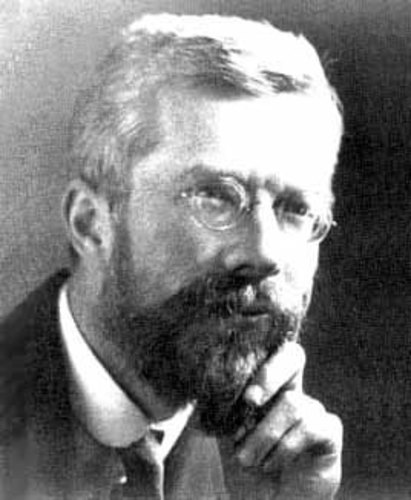

## Ronald A. Fisher

- *Statistical Methods for Research Workers* (1925), *Design of Experiments* (1935)
- His **first** approach to *statistical inference*
  - Null hypothesis \(H_0\), \(\alpha\)
  - **no alternative hypothesis.**
  - *p* > .05: ignore results.
- p-value indicates **strength of evidence**
  - \(p = .001\) is **better** than \(p = .049\)

## Ronald A. Fisher

Revision: *"No scientific worker has a fixed level of significance at which from year to year, and in all circumstances, he rejects hypotheses; he rather gives his mind to each particular case in the light of his evidence and his ideas."*

- R.A. Fisher (1956), as cited in (Gigerenzer & Marewski, 2015, p.1)

## Jerzy Neyman and Egon Pearson

- Introduced the alternative hypothesis, \(H_1\)
  - Concept of a \(\beta\) error; statistical power
- \(p < \alpha\), or \(p > \alpha\)
- Binary cut-off; not **statistical evidence**
- They did **behavioral statistics**

## Neyman-Pearson

> *no test based on probability theory can provide evidence of truth or falsehood. BUT it might govern our behavior, in following which we ensure that in the long run of experience, we shall not be too often wrong.*
- Neyman and Pearson (1933), as cited in (Johansson, 2011, p.118)

## Unification / bastardization

- 1940s/1950s
  - Psychologists (Guilford) combine both approaches in statistics textbooks
  - Ignoring differences in names (Fisher vs. Neyman & Pearson) and fundamentals (alternative hypothesis vs. none, fixed alpha vs. not)
- Current statistical practice: An *evilish hybrid* between those two **incompatible** paradigms

## Unification / bastardization

*statisticians "have already overrun every branch of science with a rapidity of conquest rivalled only by Attila, Mohammed, and the Colorado beetle."*

- Did Piaget ever compute a p-value?
- Did Skinner? what's with Koehler? Pavlov?

## Problems with Current Statistical Practices

## Mindless Statistics

- 1a: setup a statistical hypothesis of **no difference** or **zero correlation**
- 1b: don't specify the predictions of your research hypothesis
- 2: Use 0.05 as a convention for rejecting H0
- 3: always use this procedure (Gigerenzer, 2004)

## What is *Probability?*

- **Frequentists**, probability is the long-run relative frequency of events
  - prob. coin coming up heads: Proportion of heads in **infinite** amount of tosses
  - Asking about probability of next coin toss: **Nonsensical**
  - Next toss: Either heads, or not
  - Single events can't be assigned *probability*
- **Repeatability** becomes a crucial ingredient
- **Fisher**: Biologist, did lots of repeatable experiments

## What is *Probability?*

- Frequentists cannot talk about…
- …the probability of a 3rd world war
- …climate change
- …you failing your next exam
- …**any non repeatable event**
- Sneak peek: Single events are about **uncertainty**
- Probability conceptualized as long-run average frequency: No answer to essential question in science *"what is the probability that my hypothesis / theory is true?"*

## What is in a p-value?

*p*…

- …disproves the null hypothesis of no difference.
- …proves the alternative hypothesis.
- …indicates the probability of the null hypothesis being true.
- …indicates the probability of the alternative hypothesis being true.
- …indicates the probability of the experimental hypothesis being true.
- …indicates the probability of a wrong decision in case we reject the null hypothesis.
- …indicates that in 99% of cases we would obtain a significant result when repeating the experiment.
- …indicates the probability of the data or more extreme data given that the null hypothesis is true.

## What is in a p-value?

*p*…

- …disproves the null hypothesis of no difference.
- …proves the alternative hypothesis.
- …indicates the probability of the null hypothesis being true.
- …indicates the probability of the alternative hypothesis being true.
- …indicates the probability of the experimental hypothesis being true.
- …indicates the probability of a wrong decision in case we reject the null hypothesis.
- …indicates that in 99% of cases we would obtain a significant result when repeating the experiment.
- **…indicates the probability of the data or more extreme data given that the null hypothesis is true.**

## What is in a p-value?

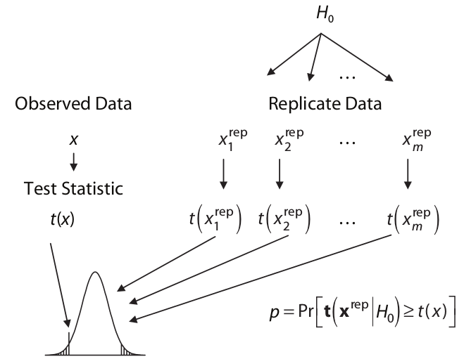

(E.-J. Wagenmakers, 2007)

## What is in a p-value?

- A frequentist **needs** this sampling distribution
- Often, properties of the sampling distribution can be derived analytically from the sample data
- Variance of the **sampling distribution** of the **sample mean** is \(\sigma^2 = \frac{s^2}{N}\)
- One reason why frequentism got so much traction: It is computationally trivial!

## The Case of Sally Clark

- both Clark's babies died, where \(p(\text{baby dies}) = \frac{1}{8543}\)
- thus the probability that both babies died is roughly 1 in 73 million
- since this is soo incredibly low (\(p < 0.00001\) or whatnot), Clark **probably killed** her babies
- indeed, in November 1999, a jury found poor Sally guilty of double murder > - see any problem with that?

## The Case of Sally Clark

> "The jury needs to weigh up two competing explanations for the babies’ deaths: SIDS or murder. The fact that two deaths by SIDS is quite unlikely is, taken alone, of little value. Two deaths by murder may well be even more unlikely. What matters is the relative likelihood of the deaths under each explanation, not just how unlikely they are under one explanation."
- **President of the Royal Statistical Society** (2002)

## The Case of Sally Clark

- in fact, \(p(\text{baby dies} | \text{sudden infant death})\) is higher than \(p(\text{baby dies} | \text{murder})\)
- the ratio of these two - the **likelihood ratio** - is the proper measure of statistical evidence
- statistical evidence is **always** relative; there is **no free lunch**

## The Wrong Probability

- p-value give you \(p(\text{D or more extreme}|H_0)\)
- what we want is \(p(H|D)\), the probability that our hypothesis is true!
- there is a subtle, but important difference
- \(p(\text{you are dead} | \text{shark has bitten off your head})\) is very high :(
- \(p(\text{shark has bitten off your head} | \text{you are dead})\) is very low!

## The Wrong Probability

- Don't quantify statistical evidence; (Wagenmakers, 2007)
- \(p = 0.04, n = 10\) is more evidence than \(p = 0.04, n = 1000\)
- in fact, the latter is support for \(H_0\)!
- are violently biased against \(H_0\)

## Effect Sizes and Confidence Intervals: The *Frequentist* Solution?

- Effect Size
  - A measure of the strength of an effect
  - e.g., a correlation of *r* = .35, a difference between experimental conditions of Cohen's *d* = 0.30
- Confidence interval
  - The area within which in 95% of replications (same experiment/measures, same sample size drawn from the same population) the real parameter (effect) will be
- Example:
  - *There was a significant difference between the control group and the intervention group, p = .002, d = 0.34 [0.22, 0.44]*

## Effect Sizes and Confidence Intervals: A Solution?

[figure not shown]

## Cumming, 2014

- *"We need to make substantial changes to how we conduct research"*

## Cumming, 2014

- Replicate (x)
- Adapt meta-analytical thinking (x)
- Avoid NHST (x)
- Don't trust any p-value (x)

## Cumming, 2014

[figure not shown]

## Cumming, 2014

- ES are the main research outcome (…?)
- The CI tells us the precision of a study (…?)
  - …a much better approach than declaring the result "statistically significant" (…?)
- "Enjoy the benefits!" (…?)

## Cumming, 2014

- So, what does a SINGLE confidence interval tell me?
- Nothing

## ES and CI are NOT the solution

### Part I: Morey et al., 2014

- "For psychological science to be a healthy science, both estimation and hypothesis testing are needed."
- Estimation is necessary in pretheoretical work before clear predictions can be made, and for theory revision.
- Hypothesis testing, not estimation, is necessary for testing the quantitative predictions of theories.
- None is more informative than the other.
- They answer different questions.
- Estimation alone produces a massive catalogue devoid of theoretical content.
- Hypothesis testing alone may cause researchers to miss rich, meaningful structure in data.
- **It is crucial for estimation and hypothesis testing to be advocated side by side.**

## ES and CI are NOT the solution

### Part II: Hoekstra et al., 2014

[figure not shown]

## ES and CI are NOT the solution

### Part II: Hoekstra et al., 2014

[figure not shown]

## ES and CI are NOT the solution

### Part III: Lee, 2014

(Lee, [here](https://webfiles.uci.edu/mdlee/Lee2014_NewStatistics.pdf))

[figure not shown]

## Confidence Intervals: A Solution?

- Effect size estimation is no solution.
- Apparently, frequentist statistics has something flawed inherent.

## Anybody read the blog?

[figure not shown]

## The principled Bayesian

## Probability as subjective belief

- "What's the probability that it will rain tomorrow"?
  - Frequentist: "That is a non-sensical question."
  - Bayesian: "I guess about 40%."
- if probabilities are subjective, don't we have a problem?
- how do we quantify them, then?

## Measuring probability

[figure not shown]

## Measuring probability

- Frank Ramsey had a gread idea (Ramsey, 1926)
- use bets to quantify subjective belief
- for 1$ in return, how much $$ would you bet on
  - Germany winning against Brazil in soccer?
  - that it is going to be at least 30?C tomorrow?

## Measuring probability

- Germany: 3$
- Weather: 5$
- these are (betting) odds
- to convert them into probability, calculate: \[ Pr = \frac{odds}{1 + odds} \]
- Germany: \(3 / (1 + 3) = .75\)
- Weather: \(5 / (1 + 5) = .83\)

## Measuring probability

- it's not about *any* subjective beliefs
- it's about subjective beliefs that obey probability
- if they do not, we can construct a *Dutch book*
- that is, a bet in which the bettor is guaranteed to lose

## Probability: Sum rule

- an urn holds \(N\) balls: \(R\) red, \(B\) blue, the rest white
- probability of drawing a red ball: \(R / N\)
- probability of drawing a coloured ball: \(R / N + B / N\)
- example from Lindley (2000)

## Probability: Product rule

- another urn holds \(N\) balls: \(R\) red, \(1 - R\) white, \(S\) spotted, \(1 - S\) plain
- given that, there are \(T\) spotted *and* red balls
- probability of drawing such a ball is: \(T / N\)
- \(\frac{T}{N} = \frac{R}{N} \times \frac{T}{R} = \frac{S}{N} \times \frac{T}{S}\)
- what does this mean?

## Probability: Product rule

RED

WHITE

SPOTTED

```
T
```

```
    S
```

PLAIN

```
  1 - S
```

```
R
```

```
 1 - R
```

```
    N
```

## Probability: Product rule

- we want to find \(P(\text{spotted}, \text{red}) = T / N\) \[ \begin{align*} P(\text{spotted}, \text{red}) &= P(\text{spotted}|\text{red})P(\text{red}) \\[1ex] \frac{T}{N} &= \frac{T}{R} \times \frac{R}{N} \\[3ex] P(\text{spotted}, \text{red}) &= P(\text{red}|\text{spotted})P(\text{spotted}) \\[1ex] \frac{T}{N} &= \frac{T}{S} \times \frac{S}{N} \end{align*} \]

## Implication of Sum rule

- \(P(\text{red}) = P(\text{red}|\text{spotted}) + P(\text{red}|\text{plain})\)
- \(P(\text{red})\) is called a marginal probability
- by summing up all the conditional probabilities, we arrive at the marginal probability

## Summing up

- we have derived the intuitive product and sum rule of probability
- this is the core of Bayesian statistics (I'm not kidding!)
- the rest is just being smart about how to apply them

## Bayes' rule: Derivation

- it's just conditional probability: \[ \begin{align} P(\text{spotted}, \text{red}) &= P(\text{spotted}|\text{red})P(\text{red}) \\[1ex] P(\text{spotted}, \text{red}) &= P(\text{red}|\text{spotted})P(\text{spotted}) \\[1ex] \end{align} \]
- which yields Bayes' Rule:

\[ \begin{align*} P(\text{spotted}|\text{red})P(\text{red}) &= P(\text{red}|\text{spotted})P(\text{spotted}) \\[1ex] P(\text{spotted}|\text{red}) &= \frac{P(\text{spotted}) \times P(\text{red}|\text{spotted})}{P(\text{red})} \end{align*} \]

## Bayes' rule: Intuition

- what is the probability of my hypothesis, p(\(H\)), given the data, \(\textbf{y}\), I have collected? \[ p(H|\textbf{y}) = \frac{p(H)p(\textbf{y}|H)}{p(\textbf{y})} \]

## Some terminology

- with parameter vector \(\theta\) and data \(\textbf{y}\): \[ \begin{align*} p(\theta|\textbf{y}) &= \frac{p(\textbf{y}|\theta)p(\theta)}{p(\textbf{y})} \\[1ex] \text{posterior} &= \frac{\text{likelihood} \times \text{prior}}{\text{marginal likelihood}} \\[2ex] \text{posterior} &\sim \text{likelihood} \times \text{prior} \end{align*} \]

## Binomial example

- first we quantify our beliefs with a prior distribution, \(p(\theta)\)
- we specify our statistical model, \(p(\textbf{y}|\theta)\)
- then we just plug in Bayes' rule, dropping the marginal likelihood: \[ p(\theta|\textbf{y}) \sim p(\textbf{y}|\theta)p(\theta) \]

## Binomial example: prior I

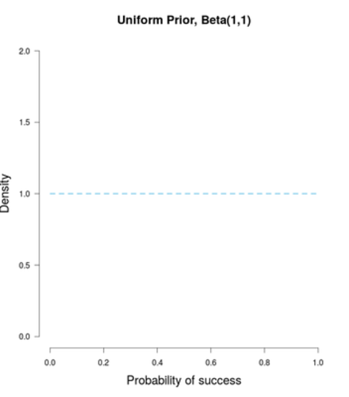

## Binomial example: prior II

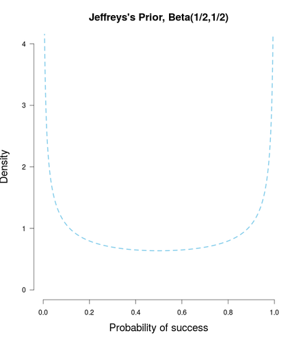

## Binomial example: prior III

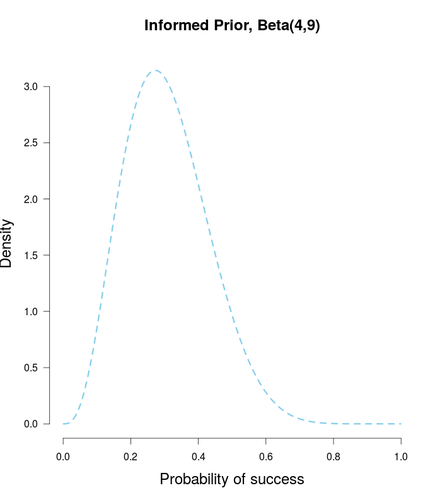

## Conjugacy

- a conjugate prior is a prior that when combined with the likelihood yields a posterior that is of the same distributional family as the prior
- the parameters of conjugate priors can be interpreted as prior data

## Binomial example: likelihood

- instead of \(p(\textbf{y}|\theta)\) we write \(\mathcal{L}(\theta; \textbf{y})\)
- for the binomial case, we use: \[ \mathcal{L}(\theta; k, N) = \theta^k \times (1 - \theta)^{N - k} \]

where \(k\) is the number of successes and \(N\) the number of data points

## Binomial example: likelihood

- likelihoods are relative, and are *not* probabilities!
- they indicate how likely the data is, given certain parameter values
- assume \(k = 2\), \(N = 4\):

\[ \begin{align*} \mathcal{L}(\theta = .5; k = 2, N = 4) = .5^2 \times (1 - .5)^{4 - 2} = .375 \\[1ex] \mathcal{L}(\theta = .9; k = 2, N = 4) = .9^2 \times (1 - .9)^{4 - 2} = .049 \end{align*} \]

## Binomial example: likelihood

- likelihoods quantify statistical evidence
- \(\theta = .5\) is \(.375 / .049 = 7.65\) times more likely than \(\theta = .9\)
- using this method, we can only compare *point* hypotheses
- later we will see how Bayes factors relax this restriction

## Binomial example: posterior

- the posterior is simply a combination of the prior and the likelihood
- in binomial settings, we a have simple updating rule: \[ \begin{align*} p(\theta) &\sim \mathcal{Beta}(a, b) \\[1ex] p(\theta|\textbf{y}) &\sim \mathcal{Beta}(a + k, b + N - k) \end{align*} \]

## Binomial example: shiny

- Visualisations from a great blog post by [Alexander Etz](http://alexanderetz.com/2015/08/09/understanding-bayes-visualization-of-bf/)
- explain:
  - Bayesian updating
  - Coherence
  - Cromwell's Rule
  - flat priors and maximum likelihood
  - convergence of initially different prior beliefs

## Why most published research findings are false

- Ioannidis (2005) argued that most published research findings are false
- common misconception:
  - \(\alpha = .05\), thus number of false positives is only 5%
  - problem: we compute \(p(\textbf{y}|H)\) and not \(p(H|\textbf{y})\)
  - ignores relevant prior information (the base rate of true hypotheses)

## Why most published research findings are false

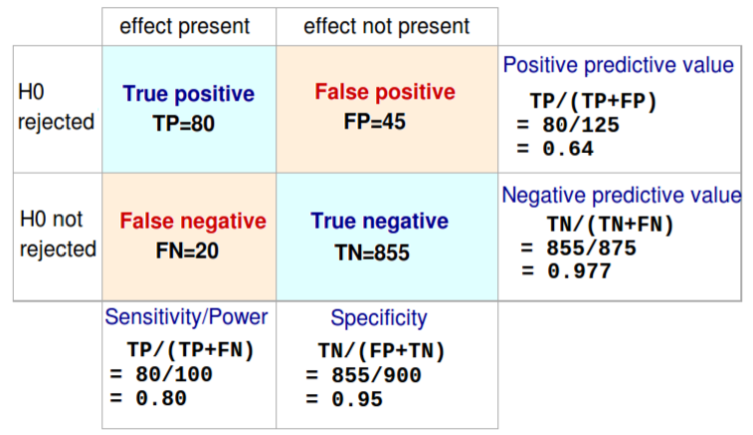

## Why most published research findings are false

\[ \begin{align*} PPV &= \frac{TP}{(TP + FP)} \\[1ex] PPV &= \frac{TP(TP + FN) / (TP + FN)}{TP (TP + FN) / (TP + FN) + FP} \end{align*} \]

- recall that:
  - \(prior = TP + FN\)
  - \(power = TP / (TP + FN)\)
- therefore: \[ PPV = \frac{power \times prior}{power \times prior + \alpha} \]

## Interim conclusion I

- to make probability statement about a hypothesis – you need a prior
- people often forget the prior (base rate), which makes them overconfident
- most published research is indeed likely to be false, due to:
  - publication bias
  - low statistical power (Button et al., 2013; Cohen, 1962)
  - statistical analysis that is contingent on data (Gelman & Loken, 2013; Simmons, Nelson, & Simonsohn, 2011)

## Interim conclusion I

- Bayesian statistics follows from probability
- it thus inherits favourable properties that classical statistics lacks
- **rationality**: if one violates Bayesian reasoning, one can systematically loose money
- **coherence**: the order of updating one's belief does not matter
- **intuitive**: it allows us to say how probable our hypothesis is after the experiment

## Model comparison

- how strongly can we believe in our hypothesis, given the collected data?
- that is, we want \(p(H|\textbf{y})\)
- a hypothesis can be instantiated in a model
- \(H_0: \delta = 0\) corresponds to a model where the parameter \(\delta\) is fixed to 0
- \(H_1: \delta \neq 0\) corresponds to a model where the parameter \(\delta\) is free to vary

## Bayes factor: Derivation

- assume two models, \(M_0\) and \(M_1\), that instantiate \(H_0\) and \(H_1\), respectively
- after we have collected data, \(p(\textbf{y})\), which model should we prefer?
- the probability of each model is computed using Bayes' rule:

\[ \begin{align} p(M_0|\textbf{y}) &= \frac{p(\textbf{y}|M_0)p(M_0)}{p(\textbf{y})} \\[1ex] p(M_1|\textbf{y}) &= \frac{p(\textbf{y}|M_1)p(M_1)}{p(\textbf{y})} \end{align} \]

## Bayes factor: Derivation

\[ \begin{align} \frac{p(M_0|\textbf{y})}{p(M_1|\textbf{y})} &= \frac{\frac{p(\textbf{y}|M_0)p(M_0)}{p(\textbf{y})}} {\frac{p(\textbf{y}|M_1)p(M_1)}{p(\textbf{y})}} \\[2ex] \frac{p(M_0|\textbf{y})}{p(M_1|\textbf{y})} &= \frac{p(M_0)}{p(M_1)}\frac{p(\textbf{y}|M_0)}{p(\textbf{y}|M_1)} \\[2ex] \text{posterior odds} &= \text{prior odds} \times \text{Bayes factor} \end{align} \]

## Bayes factor: Intuition

- the Bayes factor is an updating factor
- it tells us how to update our prior beliefs about the hypotheses, given the data
- note that there are two priors: over models \(M\), and over parameters \(\theta\)
- the term \(p(\textbf{y}|M_0)\) is the marginal likelihood under model \(M_0\)
- in other words, it is the probability of the data under model \(M_0\)
- it quantifies how well this model predicts the data

## Bayes factor: Marginal likelihood

- in parameter estimation, we have avoided this term
- now that we compare models, we cannot do so!
- often it is a high-dimensional integral, which is difficult to compute
- for \(M_0\), it is: \[ p(\textbf{y}|M_0) = \int p(\textbf{y}|\theta, M_0)p(\theta|M_0)\mathrm{d}\theta \]
- this simply follows from the sum rule discussed before
- it is a weighted average of the likelihood with respect to the prior

## Bayes factor: shiny demo

- explain:
  - Bayes factor interpretation
  - Savage-Dickey density ratio
  - parameter estimation versus hypothesis testing
  - hint at intervall null hypothesis
  - remark that Bayes factor looks at *prediction*
  - Bayes factor always interpretable – regardless of sample size

## Bayes factor: Savage-Dickey density ratio

- a neat mathematical trick to avoid computing the marginal likelihood:

\[ BF_{01} = \frac{p(\delta = 0|H_1, \textbf{y})}{p(\delta = 0|H_1)} \]

## Bayes factor: Jeffreys-Lindley's paradox

- uninformative priors should not be used
- they lead to unbounded support for \(H_0\)
- BayesFactor, JASP use default priors

## Interim conclusion II

- Bayes factor quantifies statistical evidence
- allows us to state evidence for \(H_0\)
- no issue with sequential testing
- does not depend on the sample size
- if the data are uninformative, the Bayes factor will tell you exactly that
- which is an incredibly important feature
- two deficits of *p* values:
  - depend on sample size (\(p = .03, N = 1000\) is support for \(H_0\), not \(H_1\)!)
  - if \(p > .05\), we don't know if it is due to low power, or uninformative data
  - **people literally died because of this shortcoming**

## Principled conclusion

- again, the sum and product rule are the core of Bayesian statistics
- "Bayesian" is somewhat of a misnomer
- everything follows from the sum and product rule
- the rest is just being smart on how to apply them

## The practical Bayesian

## Setup

- do hats boost creativity?

```r
set.seed(1774)

hat <- rnorm(50, 60, 10)
nohat <- rnorm(50, 50, 10)
dat <- data.frame(score = c(nohat, hat), hat = rep(0:1, each = 50))
```

## Setup

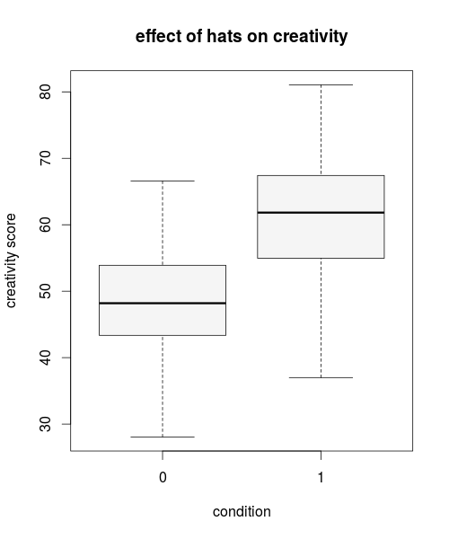

## Bayesian approach

- specify a joint distribution over parameters and data, \(p(\textbf{y}, \mu, \sigma^2)\), thus:

\[ \begin{align*} p(\mu, \sigma^2|\textbf{y}) &= \frac{p(\textbf{y}|\mu, \sigma^2)p(\mu, \sigma^2)}{p(\textbf{y})} \\[1ex] p(\mu, \sigma^2|\textbf{y}) &\sim p(\textbf{y}|\mu, \sigma^2)p(\mu, \sigma^2) \end{align*} \]

## Likelihood – our statistical model

- we assume that the data are normally distributed; for a single datum, thus: \[ \begin{equation*} \mathcal{L}(\mu, \sigma^2; y) = \frac{1}{\sqrt{2\pi\sigma^2}} \exp(\frac{-(y - \mu)^2}{2\sigma^2}) \end{equation*} \]
- assuming *exchangeability*, we can write:

\[ \begin{equation*} \mathcal{L}(\mu, \sigma^2; \textbf{y}) = \prod_{i = 1}^n \frac{1}{\sqrt{2\pi\sigma^2}} \exp(\frac{-(y_i - \mu)^2}{2\sigma^2}) \end{equation*} \]

## Likelihood – what is it?

- likelihood denotes the probability of the data, given certain fixed parameter values

\[ \begin{align*} \mathcal{L}(\mu = 40, \theta = 15; y = 50) &= .0213 \\ \mathcal{L}(\mu = 50, \theta = 15; y = 50) &= .0266 \end{align*} \]

## Prior

- In Bayesian inference, we need to formalize our belief before seeing the data
- doing this over \(\mu\) and \(\sigma^2\) simultanously is difficult
- thus we make the simplifying assumption that the priors are independent
- \(p(\mu, \sigma^2) = p(\mu)p(\sigma^2)\)
- because we are simply estimating parameters, we do not need to specify informative priors

## Prior specification

\[ \begin{align*} p(\mu) &\sim \mathcal{N}(\mu_0, \omega_0^2) \\ p(\sigma^2) &\sim \mathcal{IG}(v_0, \frac{v_0 \sigma_0^2}{2}) \end{align*} \]

- we specify a normal over \(\mu\), and an inverse gamma over \(\sigma^2\)
- this prior specification is *semi-conjugate*:

\[ \begin{align*} p(\mu|\textbf{y}, \sigma^2) &\sim \mathcal{N}(\mu, \omega^2) \\ p(\sigma^2|\textbf{y}, \mu) &\sim \mathcal{IG}(v_1, S) \end{align*} \]

where \(\omega^2\) depends on \(\sigma^2\) and \(S\) depends on \(\mu\)

## Posterior distribution

- we don't get marginal posterior distributions, \(p(\mu|\textbf{y})\) and \(p(\sigma^2|\textbf{y})\) when using independent priors
- but it is those that we want for drawing inferences!
- use **Markov chain Monte Carlo** methods (in this case: *Gibbs Sampling*)
- let's first discuss Monte Carlo on a simple example (Rouder & Lu, 2005)

## distribution of reaction times

- reaction times are not (log)normally distributed
- instead, an Ex-Gaussian distribution fits best
- it is the sum of an exponential and a Gaussian \[ x | \eta \sim \mathcal{N}(\mu + \eta, \sigma^2) \\[1ex] \eta \sim \mathcal{Exp}(\nu) \]

## distribution of reaction times

- but we do not want \(x | \eta\) (conditional probability)
- we want \(x\) (marginal probability)
- analytically, one would apply the sum rule and "integrate out" \(\nu\)
- however, that is not tractable – so instead, we use Monte Carlo methods
- this are computer based methods to solve hard problems

## Monte Carlo principle

- **anything we want to know about a random variable \(\theta\) can be learned by sampling many times from f(\(\theta\)), the density of \(\theta\)**
- in R, we can sample randomly from different probability distributions
- for example, "rnorm", "rbeta", "rgamma", "rexp"

## Monte Carlo integration

- we sample from \(\eta\) using "rexp" and use this value for \(x | \eta\) in "rnorm" \[ \eta \sim \mathcal{Exp}(\nu) \\[1ex] x | \eta \sim \mathcal{N}(\mu + \eta, \sigma^2) \]

## Monte Carlo integration

```r
exgauss <- function(mu, sigma, rate, times = 1000) {
  res <- rep(NA, times)

  for (i in 1:times) {
    nu <- rexp(1, rate)
    res[i] <- rnorm(1, mu + nu, sigma)
  }

  res
}
```

## Monte Carlo integration

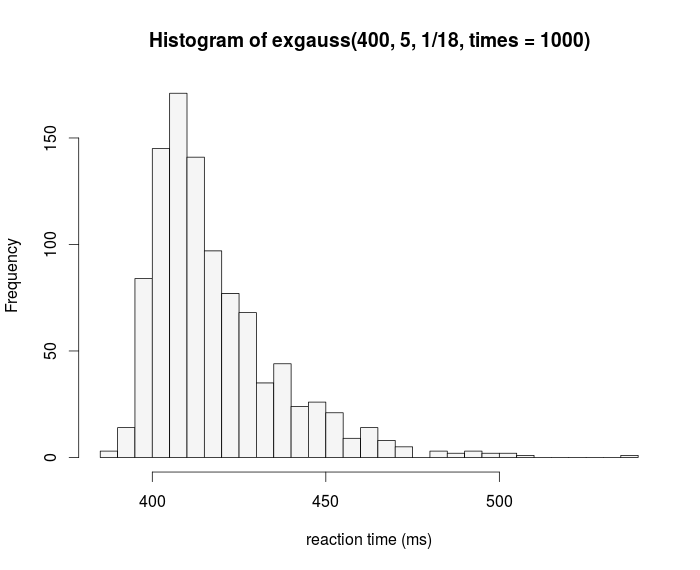

## Monte Carlo integration

- is quite a neat technique!
- let's generalize it to Gibbs Sampling
- in our creativity example, both distributions are conditional on each other
- in a sense, now we have to do monte carlo integration for both of them
- we do this iteratively, in each step drawing from both distributions, conditional on the other value

## Gibbs Sampling

```r
gibbs <- function(mu0, w0, v0, sigma0, y, n.iter = 8000, burnin = n.iter / 4) {
  n <- length(y)

  v1 <- v0 + n
  mu_post <- rep(mean(y), n.iter)
  var_post <- rep(var(y), n.iter)

  for (i in 2:n.iter) {
    mu <- mu_post[i-1]
    sigma2 <- var_post[i-1]
    w1 <- 1 / (n / sigma2 + 1 / w0^2) # condition on current variance
    mu1 <- ((n / sigma2) * mean(y) + (1 / w0^2) * mu0) / (n / sigma2 + 1 / w0^2)
    mu_post[i] <- rnorm(1, mu1, sqrt(w1))
    S <- sum((y - mu)^2) # condition on current mean
    var_post[i] <- 1 / rgamma(1, v1 / 2, S / 2)
  }
  cbind(mu_post, var_post)[-(1:burnin), ]
}
```

## Gibbs Sampling

- why is this called a Markov chain Monte Carlo technique?
- Markov chain because the values are dependent on each other
- we don't want this, so we "burn-in" the first few samples
- we can also do thinning – only keep every second draw
- it is important to check convergence

## Posterior distributions

- for parameter estimation we can specify uninformative priors: \[ \begin{align} \omega_0^2 = 1000 \\ \nu_0 = .0001 \\ \sigma_0^2 = .0001 \end{align} \]

## Posterior distributions

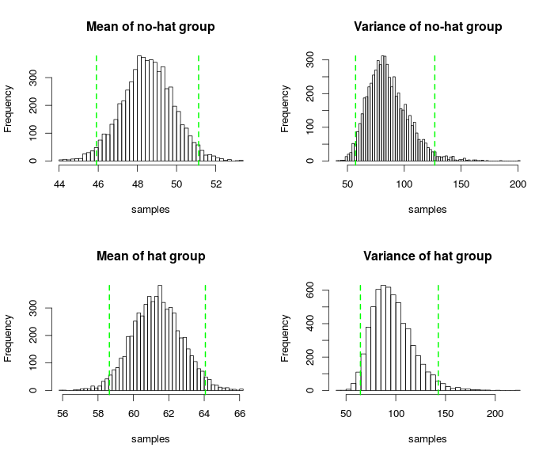

## Is our model adequate?

- the Bayes factor is relative
- just because a model is favoured very strongly against another, doesn't make it any good
- we have to check for the model's adequacy – against the real world
- in a Bayesian setting, this is done using *posterior predictive checks*
- we simulate data from our model and check if it gravely misrepresents the observed data

## Posterior predictive checks

- more formally, we compute: \[ p(\textbf{y}_{rep}|\textbf{y}) = \int p(\textbf{y}_{rep},|\theta)p(\theta|\textbf{y})\mathrm{d}\theta \]
- we can then use plots and visualisations to assess possible discrepancies

## Posterior predictive checks: no-hat condition

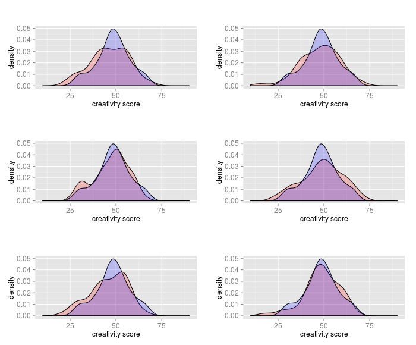

## Posterior predictive checks: hat condition

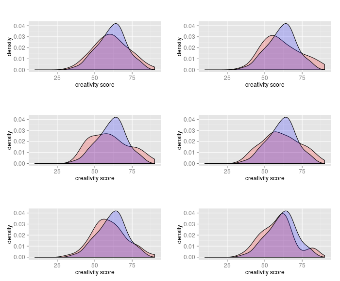

## Posterior predictive checks

- alright – but we might want to quantify the discrepancy
- and test whether there is *significant* deviation
- yes, I just used the word *significant*
- for each posterior predictive sample, we can apply a function *T* which returns some value of interest (test statistic)
- this yields a distribution of those values
- we can then apply the function to our observed data, and see if the outcome is extreme w.r.t. to the distribution

## Posterior predictive *p* values

- formally, we compute: \[ p = p(T(y_{rep}, \theta)) \geq T(\textbf{y}, \theta|\textbf{y})) \]

## Posterior predictive *p* values

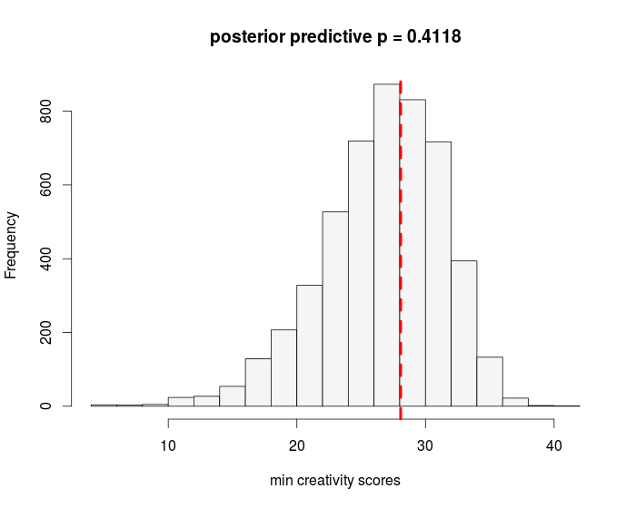

## Effect size

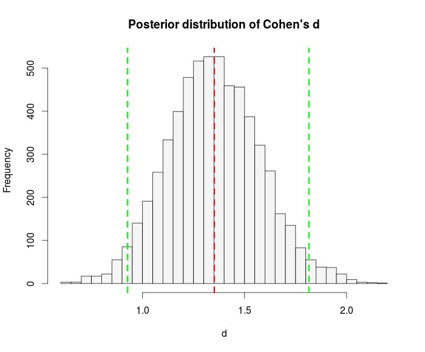

## Effect size

- in this case, it's obvious that hats make a substantial difference
- these data pass the *interocular traumatic test*
- they are so obvious – it hits you right between the eyes!
- in the real world, however, things are rarely that clear:
- "… the enthusiast's interocular trauma may be the skeptic's random error. A little arithmetic to verify the extent of the trauma can yield great peace of mind for little cost." (Edwards, Lindman, & Savage, 1963, p. 217)

## BayesFactor R-package

```r
libray('BayesFactor')

lmBF(score ~ hat, data = dat)

## Bayes factor analysis
## --------------
## [1] hat : 11448182 ±0%
##
## Against denominator:
##   Intercept only
## ---
## Bayes factor type: BFlinearModel, JZS
```

## Software for Bayesian data analysis

## JASP: Example

- developed by a research group around Jonathon Love in Amsterdam
- provides a free, open-source, modern alternative to SPSS
- does frequentist as well as Bayesian inference
- computes Bayes factors – providing us with a great peace of mind

## JASP: Example

*Turning the hands of time - with kitchen rolls!*

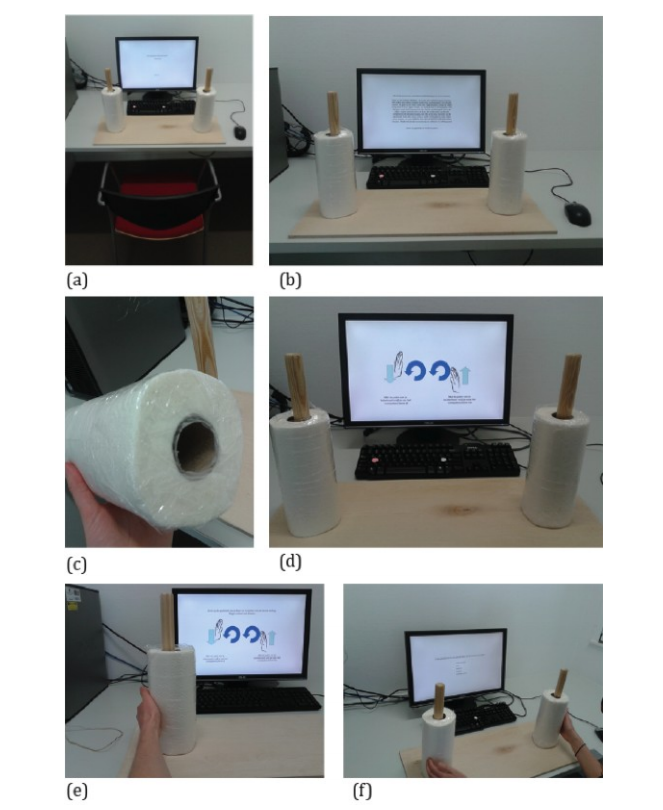

## Exercise

## JASP: Example

- you can find the pre-registration form of this research [here](https://osf.io/p3isc/), see the section **sampling plan**
- they failed to replicate the effect; the data were about 10 times more likely under \(H_0\) then under \(H_1\)
- descriptives point in the other direction than originally observed (higher openness when counter clock wise)

## JASP: Example

*Bathing habits - compensating loneliness wit heat!*

- lonely people compensate the lack of social warmth by taking warmer showers and baths (Bargh & Shalev, 2012)
- ummmmmmm, really?
- Donnellan, Lucas, & Cesario (2014) tried to replicate this in 9 experiments with over 3000 participants
- Wagenmakers E.-J., Verhagen, & Ly (In Press) re-analysed the data using Bayesian inference

## Exercise

## JASP: Example

- *p* values are uniformly distributed under \(H_0\)
- Difference: \(p > 0.05\), the data are uninformative vs. \(p > 0.05\), the data are informative and support \(H_0\)
- Frequentist statistics: We don't know which one is the case
- Bayesfactor: We know which one is the case! -> Quantifies support for \(H_0\)

## Questions

## Dataset

- Executive functions, intelligence, personality, **creativity** + insight

[figure not shown]

- *N* = 230 university students

## Bayesian SEM

Structural Equation Modeling

- Analysis of (variance) **covariance** (mean) structures
  - Compare whether "theoretically allowed" parameter estimates suffice to approximate empirical data

[figure not shown]

## Bayesian SEM

Structural Equation Modeling

- Analysis of (variance) **covariance** (mean) structures
  - Compare whether "theoretically allowed" parameter estimates suffice to approximate empirical data

[figure not shown]

## Bayesian SEM

Structural Equation Modeling

- Analysis of (variance) **covariance** (mean) structures
  - Compare whether "allowed" parameter estimates suffice to approximate empirical data
- Emphasis on *latent variables*
  - Non-observed variables representing psychological constructs
  - Get rid of measurement error
- Highly flexible approach

## Bayesian SEM: Descriptives

[figure not shown]

## Bayesian SEM: Descriptives

[figure not shown]

## Bayesian SEM: Descriptives

[figure not shown]

## Bayesian SEM: t-test

[figure not shown]

## Bayesian SEM: t-test

[figure not shown]

## Bayesian SEM: (Multiple) Regression/AN(C)OVA/GLM

[figure not shown]

## Bayesian SEM: (Multiple) Regression/AN(C)OVA/GLM

[figure not shown]

## Bayesian SEM: RMANOVA

[figure not shown]

## Bayesian SEM: RMANOVA + SEM freedom

[figure not shown]

## Bayesian SEM: RMANOVA + SEM freedom

[figure not shown]

## Bayesian SEM: RMANOVA + SEM freedom

Latent growth model

[figure not shown]

## Bayesian SEM: RMMANOVA -> Cross-lagged model

[figure not shown]

## Bayesian SEM: CFA

approximate MI -> van de Schoot et al., 2013B

## Bayesian SEM: Group Comparisons

- Mean comparisons
- Multigroup CFA

## Bayesian SEM

- Break out of schematic statistical testing
  - There is no sense in sticking to "t-test", "ANOVA", "MANOVA", "ANCOCA", "RMANOVA"
  - Cross the borders, build **your own** model

## A1. Reporting Bayesian Analysis

- Prior choice (informative/non-informative, rationales)
- Convergence: Trace plots (for important parameters)
  - see also van de Schoot et al., 2013

## A2. Literature

**JEPS Bulletin blog posts:** http://blog.efpsa.org/2014/11/17/bayesian-statistics-what-is-it-and-why-do-we-need-it-2/ http://blog.efpsa.org/2015/08/03/bayesian-statistics-why-and-how/

**Application in R and Mplus:** van de Schoot, R., Kaplan, D., Denissen, J., Asendorpf, J. B., Neyer, F. J., & van Aken, M. A. (2013). A gentle introduction to Bayesian analysis: Applications to developmental research. Child Development, 85, 841-860. doi:10.1111/cdev.12169

**Application in R:** Kruschke, J. K. (2014). Doing bayesian data analysis: A tutorial with R, JAGS, and Stan (2nd ed.). Academic Press.

**Bayesian SEM in Mplus:** Kaplan & Depaoli (2012). Bayesian Structural Equation Modeling. In: Hoyle, R. H.(Ed): Handbook of Structural Equation Modeling. pp.650-673. Guilford Press.

## A3. Software

(From most user-friendly to most elaborate)

- JASP http://jasp-stats.org
- BayesFactor http://bayesfactorpcl.r-forge.r-project.org
- Mplus http://statmodel.com/
  - Kaplan & Depaoli, 2012; van de Schoot et al., 2013
- JAGS http://mcmc-jags.sourceforge.net
- Stan http://mc-stan.org

## ReferencesI

Barker, D. H., Rancourt, D., & Jelalian, E. (2014). Flexible Models of Change: Using Structural Equations to Match Statistical and Theoretical Models of Multiple Change Processes. Journal of Pediatric Psychology, 39(2), 233-245. http://doi.org/10.1093/jpepsy/jst082

Van de Schoot, R., Kaplan, D., Denissen, J., Asendorpf, J. B., Neyer, F. J., & van Aken, M. A. G. (2013). A Gentle Introduction to Bayesian Analysis: Applications to Developmental Research. Child Development, 85, 841-860. http://doi.org/10.1111/cdev.12169

Van de Schoot, R., Kluytmans, A., Tummers, L., Lugtig, P., Hox, J., & Muth?n, B. (2013). Facing off with Scylla and Charybdis: a comparison of scalar, partial, and the novel possibility of approximate measurement invariance. Frontiers in Psychology, 4. http://doi.org/10.3389/fpsyg.2013.00770

## References

Bargh, J. A., & Shalev, I. (2012). The substitutability of physical and social warmth in daily life. *Emotion*, *12*(1), 154.

Button, K. S., Ioannidis, J. P., Mokrysz, C., Nosek, B. A., Flint, J., Robinson, E. S., & Munaf ò, M. R. (2013). Power failure: why small sample size undermines the reliability of neuroscience. *Nature Reviews Neuroscience*, *14*(5), 365–376. doi:10.1038/nrn3475

Cohen, J. (1962). The statistical power of abnormal-social psychological research: A review. *Journal of Abnormal and Social Psychology*, *65*(3), 145–153.

Donnellan, M. B., Lucas, R. E., & Cesario, J. (2014). On the association between loneliness and bathing habits: Nine replications of Bargh and Shalev (2012) study 1.

Edwards, W., Lindman, H., & Savage, L. J. (1963). Bayesian statistical inference for psychological research. *Psychological Review*, *70*(3), 193–242.

Gelman, A., & Loken, E. (2013). The garden of forking paths: Why multiple comparisons can be a problem, even when there is no “fishing expedition” or “p-hacking” and the research hypothesis was posited ahead of time. *Downloaded January*, *30*, 2014.

Gigerenzer, G. (2004). Mindless statistics. *The Journal of Socio-Economics*, *33*(5), 587–606. doi:10.1016/j.socec.2004.09.033

Gigerenzer, G., & Marewski, J. N. (2015). Surrogate Science: The Idol of a Universal Method for Scientific Inference. *Journal of Management*, *41*(2), 421–440. doi:10.1177/0149206314547522

Johansson, T. (2011). Hail the impossible: p-values, evidence, and likelihood. *Scandinavian Journal of Psychology*, *52*(2), 113–125. doi:10.1111/j.1467-9450.2010.00852.x

Lindley, D. V. (2000). The philosophy of statistics. *The Statistician*, *49*(3), 293–337.

Rouder, J. N., & Lu, J. (2005). An introduction to Bayesian hierarchical models with an application in the theory of signal detection. *Psychonomic Bulletin & Review*, *12*(4), 573–604.

Simmons, J. P., Nelson, L. D., & Simonsohn, U. (2011). False-positive psychology: undisclosed flexibility in data collection and analysis allows presenting anything as significant. *Psychological Science*, *22*(11), 1359–1366. doi:10.1177/0956797611417632

Wagenmakers, E.-J. (2007). A practical solution to the pervasive problems of p values. *Psychonomic Bulletin and Review*, *14*(5), 779–804.

Wagenmakers, E.-J., Verhagen, A.J., & Ly, A. (In Press). How to quantify evidence for the absence of a correlation. *Behavior Research Methods*.